# Yellow Fever Data Analysis

# Cross-section data Analysis

In this specific case, we use a standart logistic regression for classification.

## Reading the data

```r
cross_section <- read_excel('Casos_Hum2017_tese.xlsx') %>% filter(CLASSIF_FINAL =='CONFIRMADO' ) %>%
  select(ID=ID_BM,EVOLUCAO,ASL=TGO,ALT=TGP,Creatinine=CREATININA,Diarrhea=DIARREIA,BD,BT,Urea=UREIA,Fever=FEBRE,Nausea=NAUSEA,Hemorrhage=HEMORRAGIA,Age=IDADE,Sex=SEXO,Jaundice=ICTERICIA) %>% filter(!is.na(EVOLUCAO)) %>%
  mutate(Outcome = ifelse(EVOLUCAO=='OBITO',1,0)) %>% mutate_at(.vars = c('BD','BT'), .funs = as.numeric) %>% select(-EVOLUCAO) %>%
  mutate_at(.vars=c('Diarrhea','Fever','Nausea','Hemorrhage','Jaundice'),function(x){ifelse(x=="SIM",'Yes','No')})
```

## Missing values

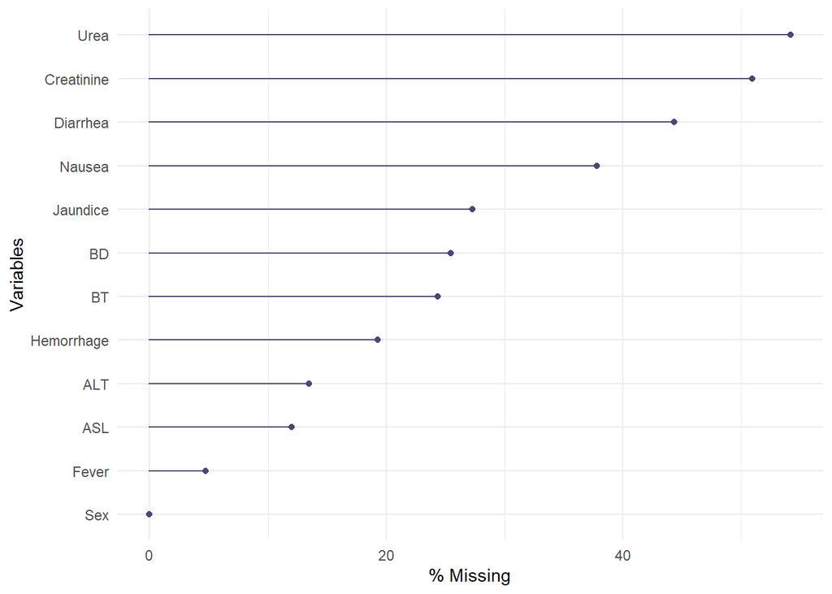

```r
summary_missing <- cross_section %>%ungroup %>%
  miss_var_summary()
not_missing <-summary_missing %>% filter(n_miss==0) %>% select(variable) %>% pull()
gg_miss_var(cross_section %>% select(-c(ID,Age,Outcome)),show_pct=TRUE)
```

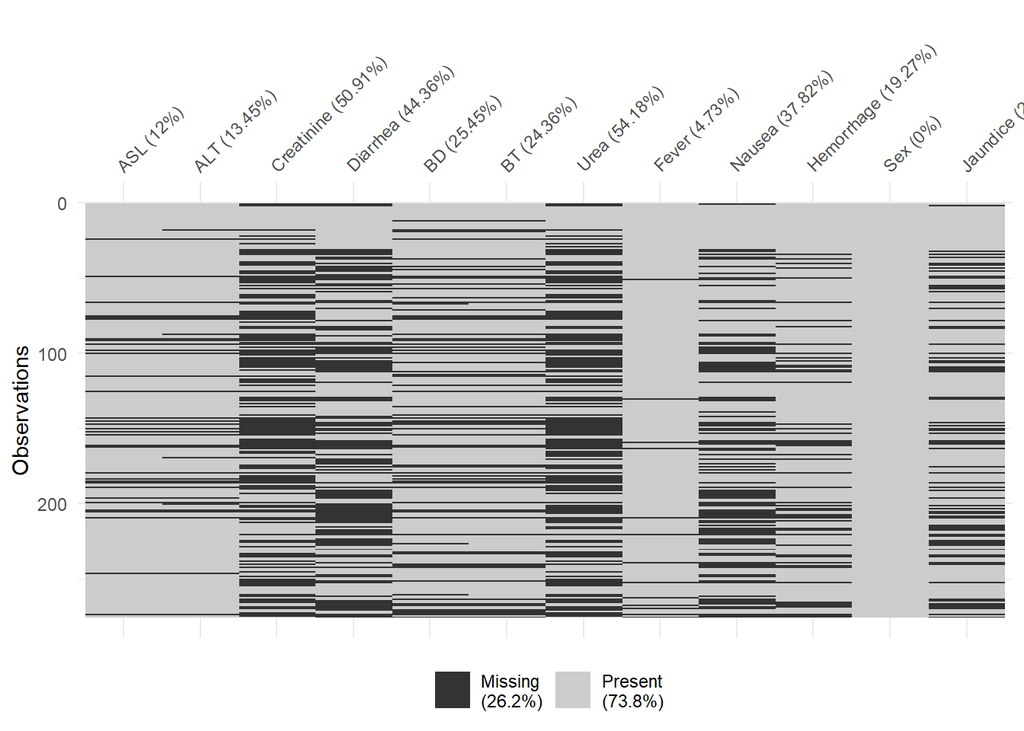

```r
vis_miss(cross_section%>% select(-c(ID,Age,Outcome)))
```

Here we can see that some variables have a high percentage of missing values. Given that this dataset is small, dealing with missing values via value inputation could have negative outcomes. With that in mind, we should avoid using more than one variable with missing percentage greater than 20% in the model fit and in no way use variables where missing values have a lower correlation per observation.

## Brief Exploratory data analysis

### ASL plot

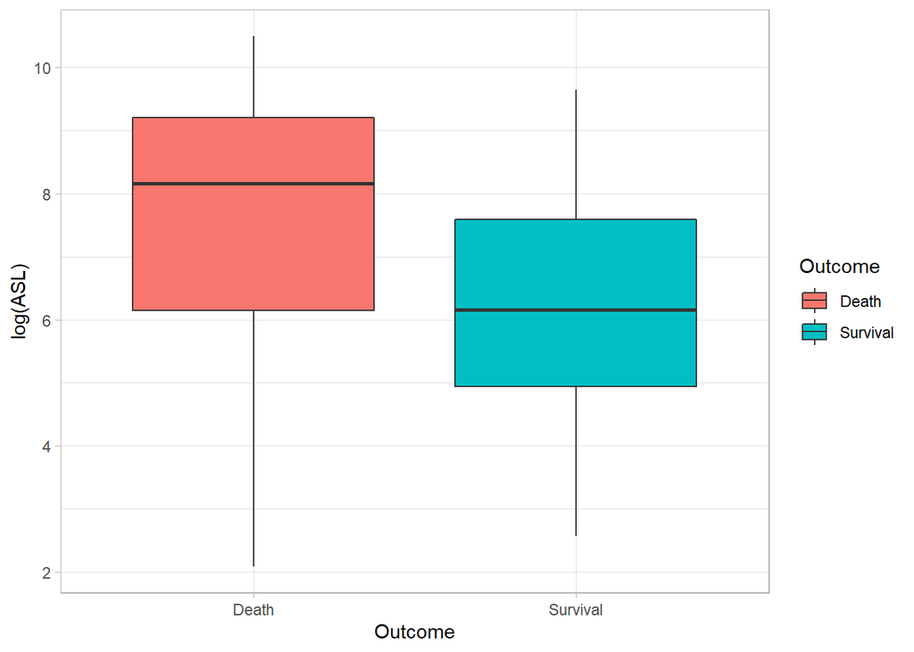

```r
ggplot(data=cross_section  %>% mutate(Outcome=ifelse(Outcome==1,"Death","Survival")),aes(y=log(ASL),fill=Outcome,x=Outcome))+
  geom_boxplot()+theme_light()
```

### BT plot

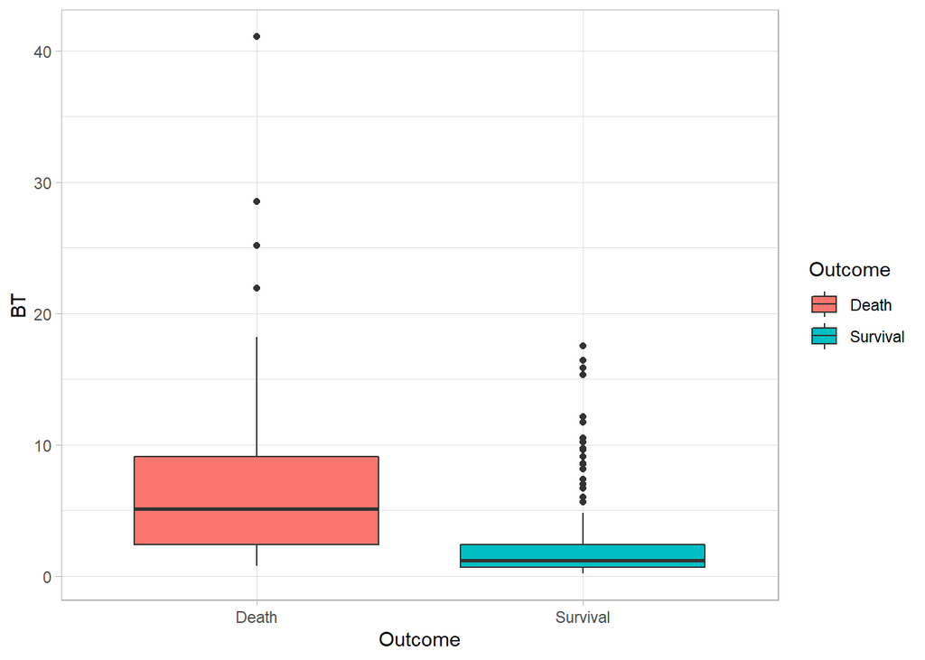

```r
ggplot(data=cross_section  %>% mutate(Outcome=ifelse(Outcome==1,"Death","Survival")),aes(y=BT,fill=Outcome,x=Outcome))+
  geom_boxplot()+theme_light()
```

### Creatinine plot

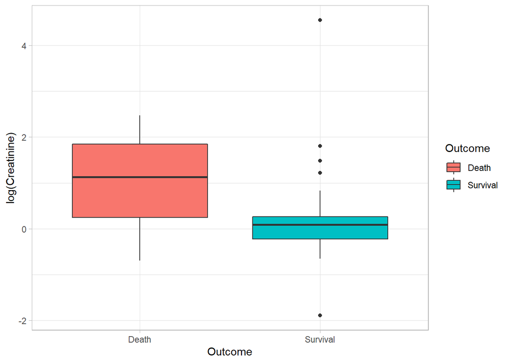

```r
ggplot(data=cross_section  %>% mutate(Outcome=ifelse(Outcome==1,"Death","Survival")),aes(y=log(Creatinine),fill=Outcome,x=Outcome))+
  geom_boxplot()+theme_light()
```

### Dichotomous covariates tables

|  | 0 | 1 |
| --- | --- | --- |
| No | 76 | 17 |
| Yes | 47 | 60 |

|  | No | Yes |
| --- | --- | --- |
| No | 76 | 16 |
| Yes | 55 | 38 |

|  | No | Yes |
| --- | --- | --- |
| No | 4 | 88 |
| Yes | 3 | 103 |

|  | No | Yes |
| --- | --- | --- |
| No | 41 | 42 |
| Yes | 23 | 46 |

|  | No | Yes |
| --- | --- | --- |
| No | 65 | 17 |
| Yes | 44 | 20 |

## Covariates correlation plot

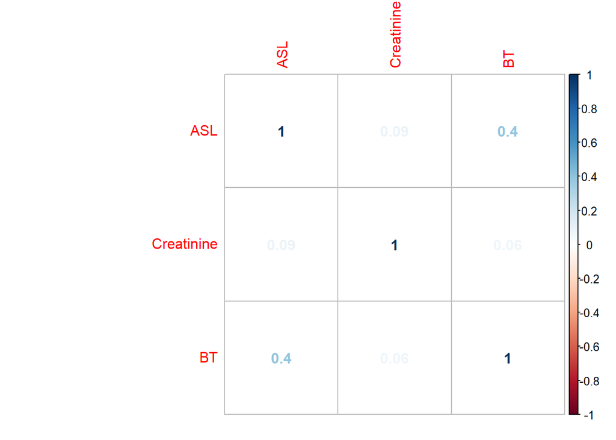

```r
M <- cor(cross_section %>% select(ASL,Creatinine,BT) %>% drop_na)
corrplot(M, method = "number")
```

It’s quite clear there is some degree of difference between variables in each group so an argument can be made that it is indeed possible to make a classification attempt on this dataset.

## Model fit

```r
logistic_fit <-glm(Outcome ~ log(ASL)+Jaundice+Hemorrhage+Age+Sex,
  data=cross_section, family=binomial(link='logit'))
logistic_fit %>% summary
```

```
##
## Call:
## glm(formula = Outcome ~ log(ASL) + Jaundice + Hemorrhage + Age +
##     Sex, family = binomial(link = "logit"), data = cross_section)
##
## Deviance Residuals:
##     Min       1Q   Median       3Q      Max
## -2.3828  -0.6867  -0.3413   0.6981   2.6591
##
## Coefficients:
##               Estimate Std. Error z value Pr(>|z|)
## (Intercept)   -7.04620    1.33277  -5.287 1.24e-07 ***
## log(ASL)       0.51916    0.12126   4.281 1.86e-05 ***
## JaundiceYes    0.94381    0.41497   2.274  0.02294 *
## HemorrhageYes  2.46357    0.50137   4.914 8.94e-07 ***
## Age            0.03624    0.01334   2.715  0.00662 **
## SexM          -0.10786    0.53902  -0.200  0.84140
## ---
## Signif. codes:  0 '***' 0.001 '**' 0.01 '*' 0.05 '.' 0.1 ' ' 1
##
## (Dispersion parameter for binomial family taken to be 1)
##
##     Null deviance: 223.28  on 167  degrees of freedom
## Residual deviance: 152.12  on 162  degrees of freedom
##   (107 observations deleted due to missingness)
## AIC: 164.12
##
## Number of Fisher Scoring iterations: 5
```

The model fitness seems fairly adequate and althoug `SEX` is not significant we will keep it in the model as a control variable.

The estimated coeeficients can be interpreted as such:

- Each 1 unit increase in the logarithm transformation of the ASL value increases on average the odds ratio of death exp(0.51916)=1.680615 times.
- The obversation of Jaundice on the subject increases on average the odds ratio of death exp(0.94381)=2.569754 times.
- The obversation of Hemorrhage on the subject increases on average the odds ratio of death exp(2.46357)=11.74667 times.
- Each additional year of age increases on average the odds ratio of death exp(0.03624) times.

## Prediction analysis

```r
prob=predict(logistic_fit,type=c("response"))
dados_roc <- cross_section %>%ungroup %>%
  select(ASL,Jaundice,Hemorrhage,Outcome) %>% drop_na() %>% mutate(p= prob)
require(pROC)
g <- auc(Outcome ~ p, data = dados_roc)
g
```

```
## Area under the curve: 0.8657
```

```r
dados_roc <- dados_roc %>% ungroup %>% mutate(prediction = ifelse(p>0.4,1,0))
confusionMatrix(dados_roc$prediction %>% as.factor,dados_roc$Outcome%>% as.factor,positive='1')
```

```
## Confusion Matrix and Statistics
##
##           Reference
## Prediction  0  1
##          0 86 12
##          1 18 52
##
##                Accuracy : 0.8214
##                  95% CI : (0.755, 0.8762)
##     No Information Rate : 0.619
##     P-Value [Acc > NIR] : 1.013e-08
##
##                   Kappa : 0.6281
##
##  Mcnemar's Test P-Value : 0.3613
##
##             Sensitivity : 0.8125
##             Specificity : 0.8269
##          Pos Pred Value : 0.7429
##          Neg Pred Value : 0.8776
##              Prevalence : 0.3810
##          Detection Rate : 0.3095
##    Detection Prevalence : 0.4167
##       Balanced Accuracy : 0.8197
##
##        'Positive' Class : 1
##
```

Usually is advised to split the data into training and testing sets to avoid overfiting but given the small data set and the nature of the problem the results are satisfying.

# Longitudinal data Analysis

The following analysis is based on a second data set consisting of 100 individuals observed throughout several days.Just like the analysis analysis before, our interst is to create a model that can better predict if and individual with a confirmed case of yellow fever will survive the disease given certain obversed symptoms and medical exams results.

## Missing data

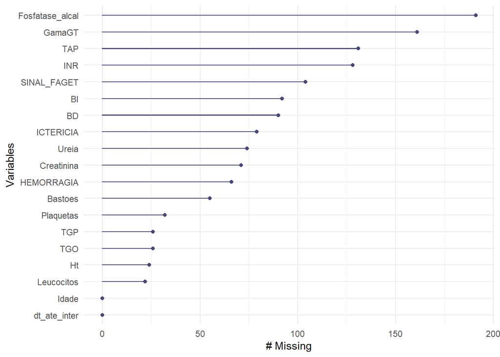

```r
summary_missing <- dados_class %>%ungroup %>%
  miss_var_summary()
not_missing <-summary_missing %>% filter(n_miss==0) %>% select(variable) %>% pull()
gg_miss_var(dados_class %>% ungroup %>%
    select(-c(pac,dt_inic,dia_doenca,DATA_FINAL,Desfecho,SEXO)))
```

Devemos evitar utilizar variáveis com muitos valores faltantes

## Inputação de valores utilizando substituindo o valor faltante pelo registro do dia anterior.

Caso o registro do dia anterior também esteja faltante, o registro do dia posterior é utilizado.

```r
dados_class_fill <- dados_class %>%group_by(pac) %>%
  fill(c("Plaquetas","Ht",'TGP','Ureia','TGO','Creatinina','ICTERICIA','BD',
         'BI','TAP','INR','Leucocitos'),.direction="updown")
```

## Covariates Analysis

### INR

[figure not shown]

```r
#png("Creatinina1.png", units="in", width=8, height=5, res=300)
ggplot(data=dados_plot %>% filter(dia_doenca>0) %>% mutate(Outcome=Desfecho),aes(y=INR,fill=Outcome,x=as.factor(dia_doenca)))+
  geom_boxplot()+xlab("Dia de doença")+theme_light()+
  scale_fill_manual(labels = c('Survival','Death'),values=c('cadetblue3','firebrick1'))+xlab('Time of disease')+
  ylab('Creatinine')+
  ggtitle('Creatinine levels by time of disease')
```

[figure not shown]

```r
# dev.off()
# png("Creatinina2.png", units="in", width=8, height=5, res=300)
ggplot(dados2 %>% mutate(Outcome = as.factor(Desfecho)),aes(dia_doenca,INR,group=pac,color=Outcome)) +
  stat_smooth(method='lm',se=F)+
  theme_light()+
  scale_color_manual(labels = c('Survival','Death'),values=c('cadetblue3','firebrick1'))+xlab('Time of disease')+
  ylab('Creatinine')+
  ggtitle('Creatinine levels by time of disease')
```

```r
# dev.off()
```

### ASL

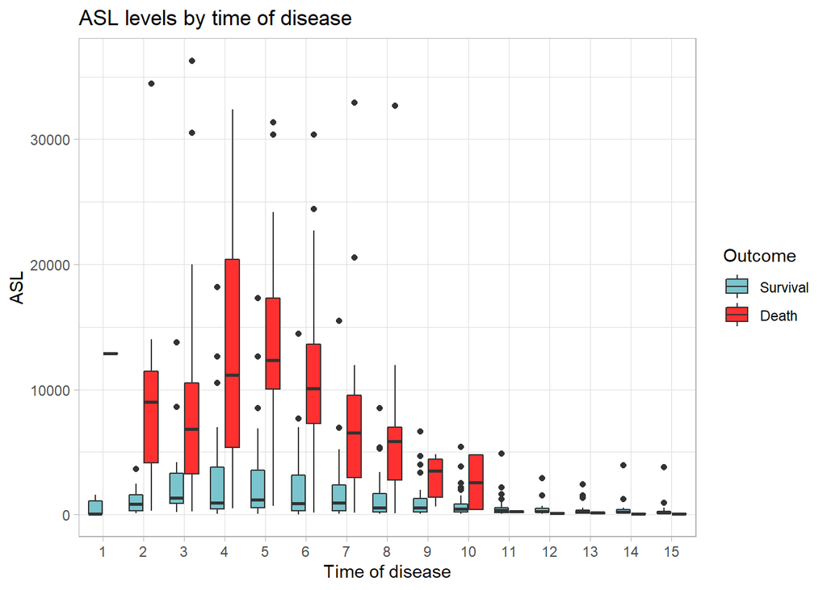

```r
# png("TGO1.png", units="in", width=8, height=5, res=300)
ggplot(data=dados_plot %>% filter(dia_doenca>0) %>% mutate(Outcome=Desfecho),aes(y=TGO,fill=Outcome,x=as.factor(dia_doenca)))+
  geom_boxplot()+xlab("Dia de doença")+theme_light()+
  scale_fill_manual(labels = c('Survival','Death'),values=c('cadetblue3','firebrick1'))+xlab('Time of disease')+
  ylab('ASL')+
  ggtitle('ASL levels by time of disease')
```

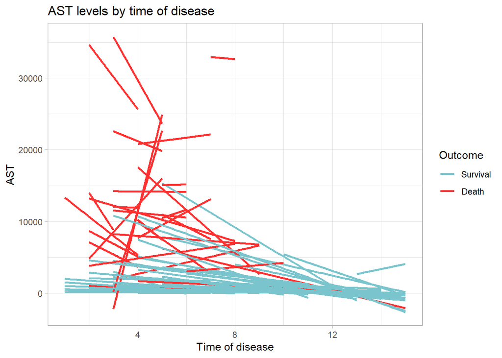

```r
# dev.off()
# png("TGO2.png", units="in", width=8, height=5, res=300)
ggplot(dados2 %>% mutate(Outcome = as.factor(Desfecho)),aes(dia_doenca,TGO,group=pac,color=Outcome)) +
  stat_smooth(method='lm',se=F) +
  theme_light()+
  scale_color_manual(labels = c('Survival','Death'),values=c('cadetblue3','firebrick1'))+xlab('Time of disease')+ylab('AST')+
  ggtitle('AST levels by time of disease')
```

```r
# dev.off()
```

### ALT

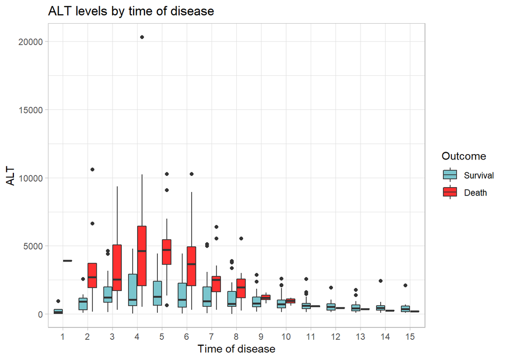

```r
# png("TGP1.png", units="in", width=8, height=5, res=300)
ggplot(data=dados_plot %>% filter(dia_doenca>0) %>% mutate(Outcome=Desfecho),aes(y=TGP,fill=Outcome,x=as.factor(dia_doenca)))+
  geom_boxplot()+xlab("Dia de doença")+theme_light()+
  scale_fill_manual(labels = c('Survival','Death'),values=c('cadetblue3','firebrick1'))+xlab('Time of disease')+
  ylab('ALT')+
  ggtitle('ALT levels by time of disease')
```

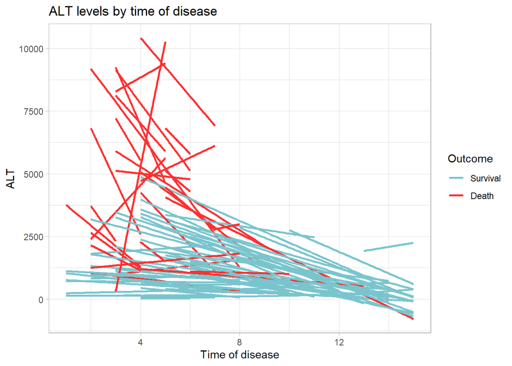

```r
# dev.off()
# png("TGP2.png", units="in", width=8, height=5, res=300)
ggplot(dados2 %>% mutate(Outcome = as.factor(Desfecho)),aes(dia_doenca,TGP,group=pac,color=Outcome)) +
  stat_smooth(method='lm',se=F) +
  theme_light()+
  scale_color_manual(labels = c('Survival','Death'),values=c('cadetblue3','firebrick1'))+xlab('Time of disease')+ylab('ALT')+
  ggtitle('ALT levels by time of disease')
```

```r
# dev.off()
```

### Platelets

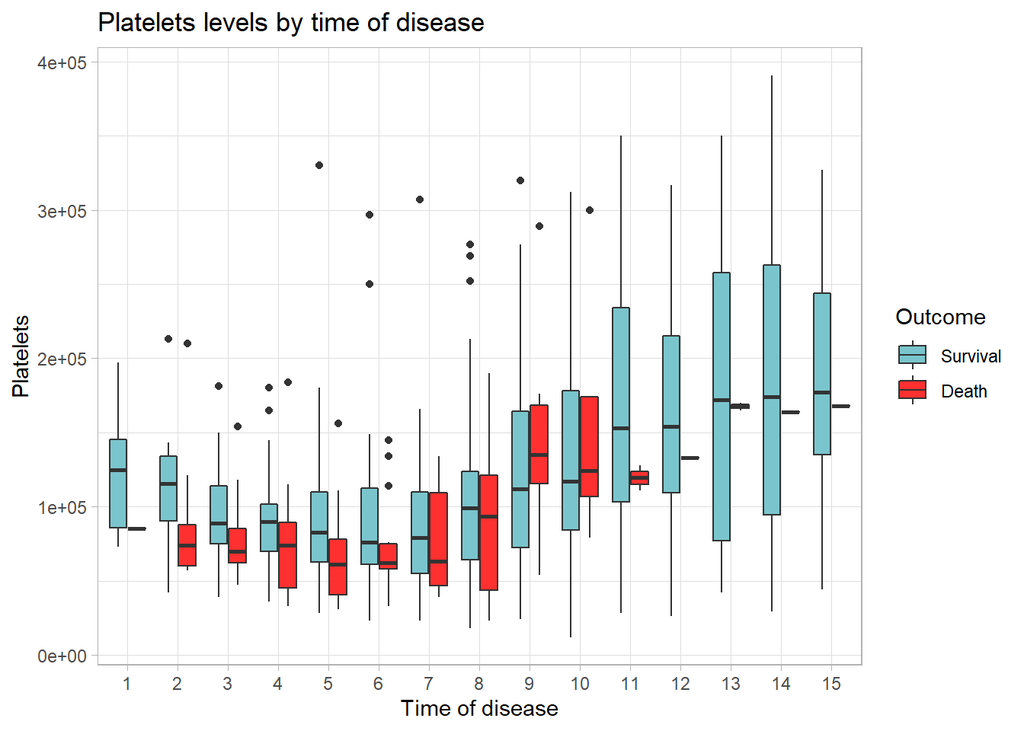

```r
# png("Plaquetas1.png", units="in", width=8, height=5, res=300)
ggplot(data=dados_plot %>% filter(dia_doenca>0) %>% mutate(Outcome=Desfecho),aes(y=Plaquetas,fill=Outcome,x=as.factor(dia_doenca)))+
  geom_boxplot()+xlab("Dia de doença")+theme_light()+
  scale_fill_manual(labels = c('Survival','Death'),values=c('cadetblue3','firebrick1'))+xlab('Time of disease')+
  ylab('Platelets')+
  ggtitle('Platelets levels by time of disease')
```

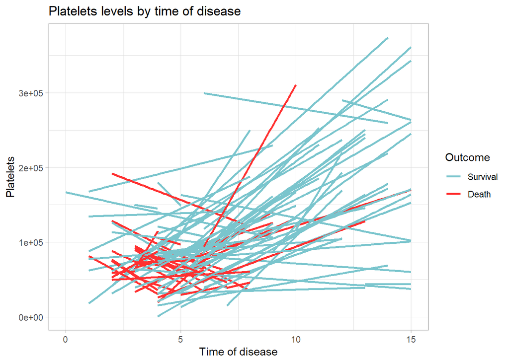

```r
# dev.off()
# png("Plaquetas2.png", units="in", width=8, height=5, res=300)
ggplot(dados2 %>% mutate(Outcome = as.factor(Desfecho)),aes(dia_doenca,Plaquetas,group=pac,color=Outcome)) +
  stat_smooth(method='lm',se=F) +
  theme_light()+
  scale_color_manual(labels = c('Survival','Death'),values=c('cadetblue3','firebrick1'))+xlab('Time of disease')+ylab('Platelets')+
  ggtitle('Platelets levels by time of disease')
```

```r
# dev.off()
```

### Leukocytes

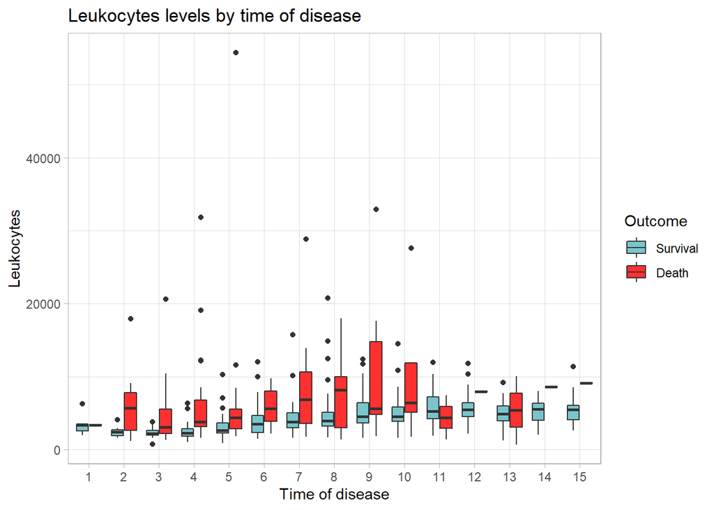

```r
# png("Leucocitos1.png", units="in", width=8, height=5, res=300)
ggplot(data=dados_plot %>% filter(dia_doenca>0) %>% mutate(Outcome=Desfecho),aes(y=Leucocitos,fill=Outcome,x=as.factor(dia_doenca)))+
  geom_boxplot()+xlab("Dia de doença")+theme_light()+
  scale_fill_manual(labels = c('Survival','Death'),values=c('cadetblue3','firebrick1'))+xlab('Time of disease')+
  ylab('Leukocytes')+
  ggtitle('Leukocytes levels by time of disease')
```

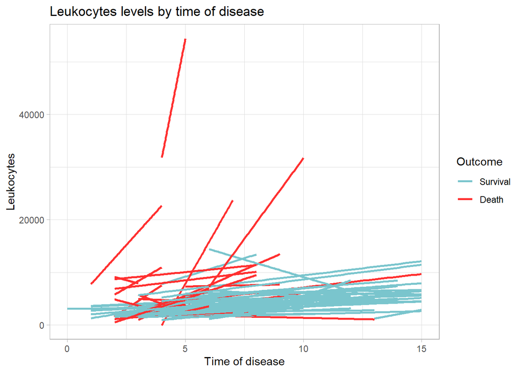

```r
# dev.off()
# png("Leucocitos2.png", units="in", width=8, height=5, res=300)
ggplot(dados2 %>% mutate(Outcome = as.factor(Desfecho)),aes(dia_doenca,Leucocitos,group=pac,color=Outcome)) +
  stat_smooth(method='lm',se=F) +
  theme_light()+
  scale_color_manual(labels = c('Survival','Death'),values=c('cadetblue3','firebrick1'))+xlab('Time of disease')+ylab('Leukocytes')+
  ggtitle('Leukocytes levels by time of disease')
```

```r
# dev.off()
```

## Correlações

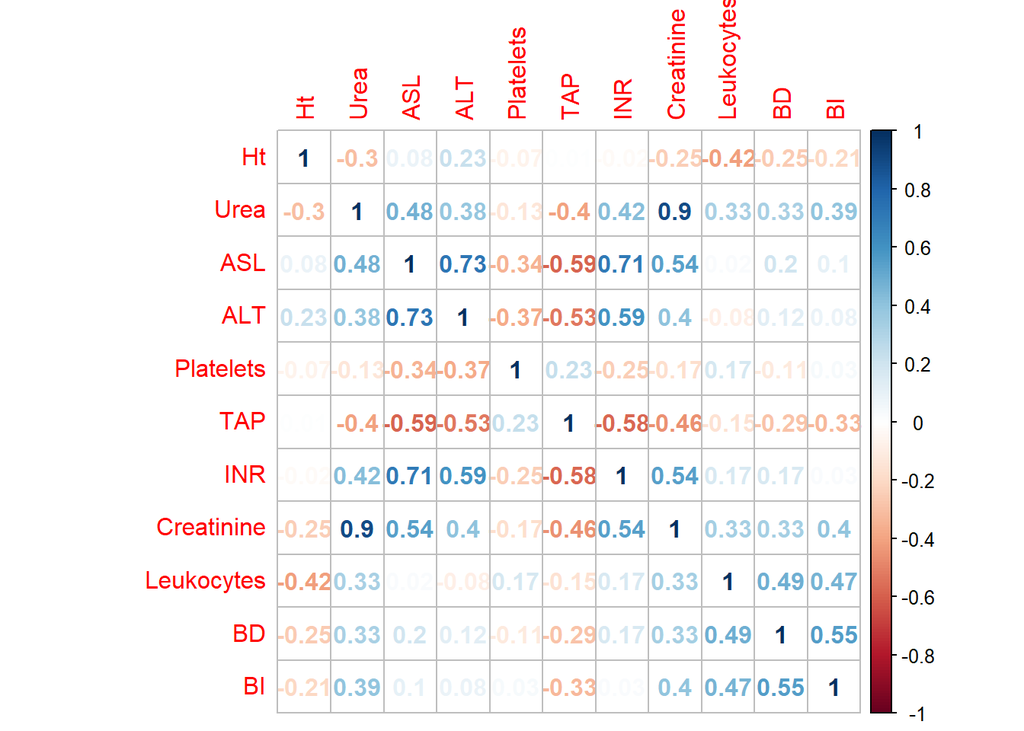

```r
require(corrplot)
M <- cor(dados_class_fill %>% ungroup%>%select(Ht,Urea=Ureia,ASL=TGO,ALT=TGP,Platelets=Plaquetas,TAP,INR,
                                               Creatinine=Creatinina,Leukocytes=Leucocitos,BD,BI)%>% drop_na()  )
# png("Correlacoes.png", units="in", width=8, height=5, res=300)
corrplot(M, method = "number")
```

```r
# dev.off()
```

Ainda existem dados faltantes de ICTERICIA que não podem ser inputados pois não existe o regristro anível de paciente.

# Aplicação de equações de estimação generalizadas (GEE)

O método de equações de estimação generalizadas (GEE) é uma alternativa para a modelagem de dados longitudinais. Essa aplicação estima efeitos médios populacionais, que satisfazem a motivação da pesquisa de obter uma análise que seja reproduzível em diferentes indivíduos.

Essa técnica de modelagem requer a indicação de uma estrutura de correlação entre os tempos observados de cada indivíduo e estima o efeito médio populacional das variáveis explicativas. Neste caso foi utilizada uma estrutura de correlação temporal baseada em um processo autoregressivo de ordem 1.

O algorítmo obtem a estimativa dos coeficientes $\beta$ através da maximização da equação abaixo em $\beta$:

$$U(\tilde\beta)=\sum\limits_{i=1}^n \frac{\partial\mu_{ij}}{\partial \beta_p}V_i^{-1}\{Y_i-\mu_i(\tilde\beta)\}$$
Onde:

- $\mu_{ij}$ é o valor da variável explicativa do indivíduo $i$ no tempo $j$.
- $\beta_p, \ p = 1,\ldots,k$ são os coeficientes das variáveis explicativas
- $V_i$ é a estrutura de correlação do indivíduo $i$.

Nessa aplicação o modelo fornence uma estimativa da probabilidade de óbito para um indivíduo infectado com o vírus da febre amarela, independe do dia de doença em que ele se encontrar a partir de uma série de covariáveis.

O modelo foi ajustado seguindo um procedimento em etapas (“step”), porém, as etapas não estão explícitas nesse código visando a simplificação do relatório. Um ponto a ser observado é o fato do GEE ser um método que utiliza a quasi-verossimilhança, sendo assim, não é possível utilizar critérios baseados na verossimilhança (AIC, BIC) para comparar ajustes de diferentes modelos, então, foi utilizado como critério de seleção de modelos a acurácia de predição.

```r
require(geepack)
dados_scaled <-  dados2  %>% mutate(TGO=log(TGO)) %>% select(-dt_inic) %>%
  ungroup %>% mutate(pac = as.factor(pac)) %>%
  select(TGO,pac,dia_doenca,Desfecho,SEXO,Idade,HEMORRAGIA,INR)%>%
  group_by(pac) %>%
  drop_na() %>% mutate(Idade = ifelse(Idade<40,'<40','>40'))

ajuste_gee <-  geeglm(Desfecho~TGO+HEMORRAGIA+SEXO+Idade+INR,id=pac, data=dados_scaled,
                   family=binomial(link='logit'),waves=dia_doenca,corstr='ar1',scale.fix = TRUE )
ajuste_gee
```

```
##
## Call:
## geeglm(formula = Desfecho ~ TGO + HEMORRAGIA + SEXO + Idade +
##     INR, family = binomial(link = "logit"), data = dados_scaled,
##     id = pac, waves = dia_doenca, corstr = "ar1", scale.fix = TRUE)
##
## Coefficients:
##   (Intercept)           TGO HEMORRAGIASIM         SEXOM      Idade>40
##    -3.8337753     0.3867210     1.6150614    -0.5731251    -0.6061328
##           INR
##     0.2640412
##
## Degrees of Freedom: 364 Total (i.e. Null);  358 Residual
##
## Scale is fixed.
##
## Correlation:  Structure = ar1    Link = identity
## Estimated Correlation Parameters:
##     alpha
## 0.8013683
##
## Number of clusters:   82   Maximum cluster size: 12
```

```r
summary(ajuste_gee)
```

```
##
## Call:
## geeglm(formula = Desfecho ~ TGO + HEMORRAGIA + SEXO + Idade +
##     INR, family = binomial(link = "logit"), data = dados_scaled,
##     id = pac, waves = dia_doenca, corstr = "ar1", scale.fix = TRUE)
##
##  Coefficients:
##               Estimate  Std.err   Wald Pr(>|W|)
## (Intercept)   -3.83378  1.33625  8.232 0.004117 **
## TGO            0.38672  0.09876 15.333 9.01e-05 ***
## HEMORRAGIASIM  1.61506  0.51067 10.002 0.001563 **
## SEXOM         -0.57313  0.86200  0.442 0.506129
## Idade>40      -0.60613  0.48231  1.579 0.208853
## INR            0.26404  0.07473 12.483 0.000411 ***
## ---
## Signif. codes:  0 '***' 0.001 '**' 0.01 '*' 0.05 '.' 0.1 ' ' 1
##
## Scale is fixed.
##
## Correlation: Structure = ar1  Link = identity
##
## Estimated Correlation Parameters:
##       Estimate Std.err
## alpha   0.8014 0.04404
## Number of clusters:   82   Maximum cluster size: 12
```

```r
anova(ajuste_gee)
```

```
## Analysis of 'Wald statistic' Table
## Model: binomial, link: logit
## Response: Desfecho
## Terms added sequentially (first to last)
##
##            Df    X2 P(>|Chi|)
## TGO         1 19.82   8.5e-06 ***
## HEMORRAGIA  1 10.46   0.00122 **
## SEXO        1  0.02   0.88557
## Idade       1  1.03   0.30986
## INR         1 12.48   0.00041 ***
## ---
## Signif. codes:  0 '***' 0.001 '**' 0.01 '*' 0.05 '.' 0.1 ' ' 1
```

## Estrutura de correlações

Foram consideradas as observações com no máximo 15 dias de doença, sendo assim, a matriz de correlação considerando valores arredondados e $alpha$ estimado conjuntamente com o ajuste do modelo é:

```r
require(geepack)
require(magrittr)
corr_struc <-  CVTuningCov::AR1(15,0.801) %>% round(2)
rownames(corr_struc)= paste("Dia",1:15)
corr_struc %<>% data.frame
df_corr <- rownames_to_column(corr_struc, "Dia")
df_corr %>% kable(col.names= c("",paste("Dia",1:15))) %>% kable_styling("bordered")%>%
  column_spec(1, bold = T,width_min = "2cm",color='black')
```

|  | Dia 1 | Dia 2 | Dia 3 | Dia 4 | Dia 5 | Dia 6 | Dia 7 | Dia 8 | Dia 9 | Dia 10 | Dia 11 | Dia 12 | Dia 13 | Dia 14 | Dia 15 |
| --- | --- | --- | --- | --- | --- | --- | --- | --- | --- | --- | --- | --- | --- | --- | --- |
| Dia 1 | 1.00 | 0.80 | 0.64 | 0.51 | 0.41 | 0.33 | 0.26 | 0.21 | 0.17 | 0.14 | 0.11 | 0.09 | 0.07 | 0.06 | 0.04 |
| Dia 2 | 0.80 | 1.00 | 0.80 | 0.64 | 0.51 | 0.41 | 0.33 | 0.26 | 0.21 | 0.17 | 0.14 | 0.11 | 0.09 | 0.07 | 0.06 |
| Dia 3 | 0.64 | 0.80 | 1.00 | 0.80 | 0.64 | 0.51 | 0.41 | 0.33 | 0.26 | 0.21 | 0.17 | 0.14 | 0.11 | 0.09 | 0.07 |
| Dia 4 | 0.51 | 0.64 | 0.80 | 1.00 | 0.80 | 0.64 | 0.51 | 0.41 | 0.33 | 0.26 | 0.21 | 0.17 | 0.14 | 0.11 | 0.09 |
| Dia 5 | 0.41 | 0.51 | 0.64 | 0.80 | 1.00 | 0.80 | 0.64 | 0.51 | 0.41 | 0.33 | 0.26 | 0.21 | 0.17 | 0.14 | 0.11 |
| Dia 6 | 0.33 | 0.41 | 0.51 | 0.64 | 0.80 | 1.00 | 0.80 | 0.64 | 0.51 | 0.41 | 0.33 | 0.26 | 0.21 | 0.17 | 0.14 |
| Dia 7 | 0.26 | 0.33 | 0.41 | 0.51 | 0.64 | 0.80 | 1.00 | 0.80 | 0.64 | 0.51 | 0.41 | 0.33 | 0.26 | 0.21 | 0.17 |
| Dia 8 | 0.21 | 0.26 | 0.33 | 0.41 | 0.51 | 0.64 | 0.80 | 1.00 | 0.80 | 0.64 | 0.51 | 0.41 | 0.33 | 0.26 | 0.21 |
| Dia 9 | 0.17 | 0.21 | 0.26 | 0.33 | 0.41 | 0.51 | 0.64 | 0.80 | 1.00 | 0.80 | 0.64 | 0.51 | 0.41 | 0.33 | 0.26 |
| Dia 10 | 0.14 | 0.17 | 0.21 | 0.26 | 0.33 | 0.41 | 0.51 | 0.64 | 0.80 | 1.00 | 0.80 | 0.64 | 0.51 | 0.41 | 0.33 |
| Dia 11 | 0.11 | 0.14 | 0.17 | 0.21 | 0.26 | 0.33 | 0.41 | 0.51 | 0.64 | 0.80 | 1.00 | 0.80 | 0.64 | 0.51 | 0.41 |
| Dia 12 | 0.09 | 0.11 | 0.14 | 0.17 | 0.21 | 0.26 | 0.33 | 0.41 | 0.51 | 0.64 | 0.80 | 1.00 | 0.80 | 0.64 | 0.51 |
| Dia 13 | 0.07 | 0.09 | 0.11 | 0.14 | 0.17 | 0.21 | 0.26 | 0.33 | 0.41 | 0.51 | 0.64 | 0.80 | 1.00 | 0.80 | 0.64 |
| Dia 14 | 0.06 | 0.07 | 0.09 | 0.11 | 0.14 | 0.17 | 0.21 | 0.26 | 0.33 | 0.41 | 0.51 | 0.64 | 0.80 | 1.00 | 0.80 |
| Dia 15 | 0.04 | 0.06 | 0.07 | 0.09 | 0.11 | 0.14 | 0.17 | 0.21 | 0.26 | 0.33 | 0.41 | 0.51 | 0.64 | 0.80 | 1.00 |

## Interpretação das variávies

Estimativas Negativas indicam diminuição na razão de chances de óbito e estimativas prositivas indicam aumento, mesma interpretação da regressão logística.

As variáveis de SEXO e idade não se mostraram significativas mas foram incluídas.

## Análise da predição

```r
prob=predict(ajuste_gee,type=c("response"))
dados_roc <- dados_scaled %>%ungroup %>%
  select(Desfecho,TGO,pac,dia_doenca) %>%
mutate(p= prob)
require(pROC)
g <- auc(Desfecho ~ p, data = dados_roc)
g
```

```
## Area under the curve: 0.896
```

```r
dados_roc <- dados_roc %>% ungroup %>% mutate(prediction = ifelse(p>0.375,1,0))
confusionMatrix(dados_roc$prediction %>% as.factor,dados_roc$Desfecho%>% as.factor,positive='1')
```

```
## Confusion Matrix and Statistics
##
##           Reference
## Prediction   0   1
##          0 233  25
##          1  33  73
##
##                Accuracy : 0.841
##                  95% CI : (0.799, 0.877)
##     No Information Rate : 0.731
##     P-Value [Acc > NIR] : 4.52e-07
##
##                   Kappa : 0.605
##
##  Mcnemar's Test P-Value : 0.358
##
##             Sensitivity : 0.745
##             Specificity : 0.876
##          Pos Pred Value : 0.689
##          Neg Pred Value : 0.903
##              Prevalence : 0.269
##          Detection Rate : 0.201
##    Detection Prevalence : 0.291
##       Balanced Accuracy : 0.810
##
##        'Positive' Class : 1
##
```

É importante notar que apesar da acurácia não ser extremamente alta (0.841), estamos falando da acurária de predição para todos os registros observados. Em alguns períodos de doença a diferenciação de indivíduos é de fato mais complexa pois a alteração de alguns exames ou sintoma pode se dar pela cura ou pelo enfraquecimento do organismo de um indivíduo perto do óbito. Considerando essa ressalva, ainda sim, o modelo tem uma performance boa com AUC de 0.896 e acurácia de predição de .841.

Uma análise de diagnóstico muito interesse que também pode ser feita é observar a probabilidade de óbito predita para os indivíduos que de fato foram a óbito no período inicial de acompanhamento.

```r
algum_acerto <- dados_roc %>% select(pac,p,Desfecho,dia_doenca) %>%group_by(pac) %>%  filter(Desfecho ==1)
algum_acerto %>%filter(p==max(p)) %>%ungroup %>%  summarise(median(p))
```

```
## # A tibble: 1 x 1
##   `median(p)`
##         <dbl>
## 1       0.730
```

```r
algum_acerto %>%filter(p==max(p)) %>%ungroup %>%  summarise(median(dia_doenca))
```

```
## # A tibble: 1 x 1
##   `median(dia_doenca)`
##                  <dbl>
## 1                    5
```

A probabilidade máxima mediana atribuída para os indivíduos que foram a óbito é de 0.73 e o tempo mediano que o valor máximo da probabilidade de óbbito foi atribuída é no quinto dia. O que essa informação nos diz é que o modelo é capaz de detectar indivíduos que poderão ir a óbito no estágios iniciais da doença com uma acurária considerável.

# Árvore de Decisão

Podemos também nos basear no primeiro registro observado para construir uma árvore de decisão para tentar prever o óbito.

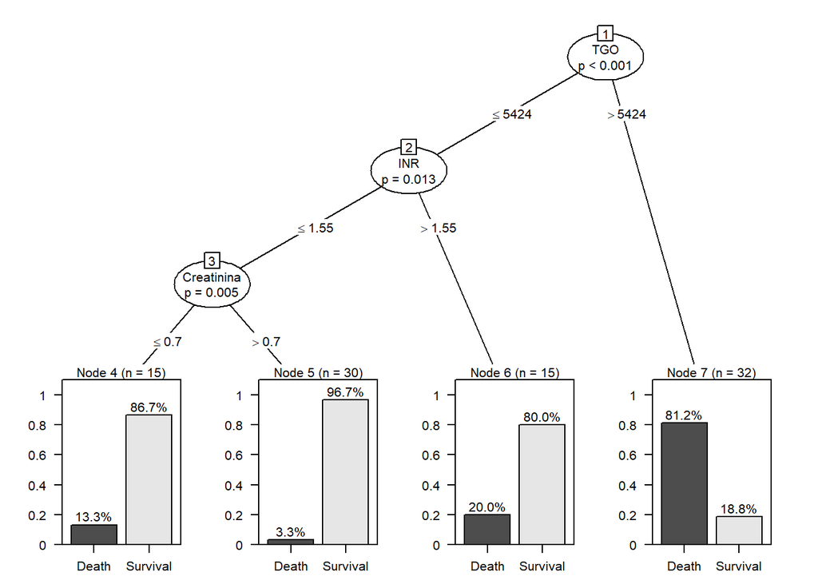

```r
require(partykit)
dados_primeira_obs= dados2   %>% select(-dt_inic) %>%
  ungroup %>% mutate(pac = as.factor(pac)) %>%
  select(TGO,pac,dia_doenca,Desfecho,SEXO,Idade,INR,Creatinina)%>%
  group_by(pac) %>%
  drop_na() %>% mutate(Idade = ifelse(Idade<40,'<40','>40')) %>% group_by(pac) %>%
  filter(dia_doenca==min(dia_doenca)) %>% ungroup %>%
    mutate(Desfecho_lab = ifelse(Desfecho==1,'Death','Survival')) %>%
  mutate_at(.vars=vars(Desfecho_lab,SEXO,Idade,dia_doenca),as.factor)

Arvore = ctree(Desfecho_lab~ Idade+SEXO+TGO+INR+Creatinina,data=dados_primeira_obs,minbucket=15)
plot(Arvore,terminal_panel = node_barplot(Arvore,beside=TRUE,text='horizontal'), gp = gpar(fontsize = 8))
```

```r
  t_pred <- predict(Arvore,dados_primeira_obs)
  t_pred_bin <- ifelse(t_pred=='Death',1,0)
confusionMatrix(t_pred_bin %>% as.factor,dados_primeira_obs$Desfecho %>% as.factor,positive='1')
```

```
## Confusion Matrix and Statistics
##
##           Reference
## Prediction  0  1
##          0 54  6
##          1  6 26
##
##                Accuracy : 0.87
##                  95% CI : (0.783, 0.931)
##     No Information Rate : 0.652
##     P-Value [Acc > NIR] : 2.19e-06
##
##                   Kappa : 0.712
##
##  Mcnemar's Test P-Value : 1
##
##             Sensitivity : 0.812
##             Specificity : 0.900
##          Pos Pred Value : 0.812
##          Neg Pred Value : 0.900
##              Prevalence : 0.348
##          Detection Rate : 0.283
##    Detection Prevalence : 0.348
##       Balanced Accuracy : 0.856
##
##        'Positive' Class : 1
##
```

Tendo em vista que a técnica utilizada pode gerar sobreajuste e não estamos usando partição de treino e teste, um número mínimo de 15 indivíduos por classe foi estabelecido, além disso, foi considerada a primeira observação registrada na observação dos dados longitudinais.

O método de árvore de decisão divide os pacientes em 4 grupos, o primeiro grupo de 15 pacientes tem taxa de sobrevivência de 86.7%. Este grupo é composto por pacientes com TGO inferior a 5424, INR inferior a 1.55 e Creatinina inferior a 0.7.

O segundo grupo, com 30 pacientes, tem taxa de sobrevivêndia de 96.7%. Este grupo é composto por pacientes com TGO inferior a 5424, INR inferior a 1.55 e Creatinina superior a 0.7.

O terceiro grupo, com 15 pacientes, tem taxa de sobrevivência de 80%. Este grupo é composto por pacientes com TGO inferior a 5424 e INR superior a 1.55.

O quarto grupo tem taxa de sobrevivência de apenas 18.8% e contém 32 pacientes. Este grupo é composto por pacientes que possuem o TGO superior a 5424.